# Battery Recycling

How can we increase recycling rates

Author

Gian Teufen

Published

June 2, 2025

# Battery Recycling

## Introduction

Because Batteries contain some toxic and valuable components that are even considered critical materials, proper recycling is crucial “Recycling of Spent Lithium-Ion Batteries as a Sustainable Solution to Obtain Raw Materials for Different Applications” (2023). Switzerland is the world’s No.1 recycling country with an 80% recycling rate of portable batteries Batrec (n.d.). The government has taken various measures in the past to increase recyling rates. For example they made the separate disposal of used batteries at designated collection points mandatory, the free-of-charge collection of used batteries from any battery consumer is obligatory for any point of sale and public education campaigns were conducted “Justifications and Self-Organization as Determinants of Recycling Behavior” (2006) “Characteristics of Effective Battery Recycling Slogans” (2009). Now the question remains of what measures to implement next.

## Methods

A survey was conducted to gather information on the respondents demographics and current recycling behavior, then four different measures were proposed and the respondents were asked to rate each measure on a Likert scale from 1 to 5. They were asked to rate the option “Education campaign” before and after reading the education content to determine whether their knowledge would influence this result. Their previous knowledge was also tested by letting them rate the significance of various consequences of improper battery recycling on a Likert scale.

## Results

- Introducing a deposit of CHF 0.50 per battery
- Halving the distance to your next collection point.
- Education campaigns about the consequences of improper disposal.
- Batteries can be removed from all devices without tools.

### Rating of Measures

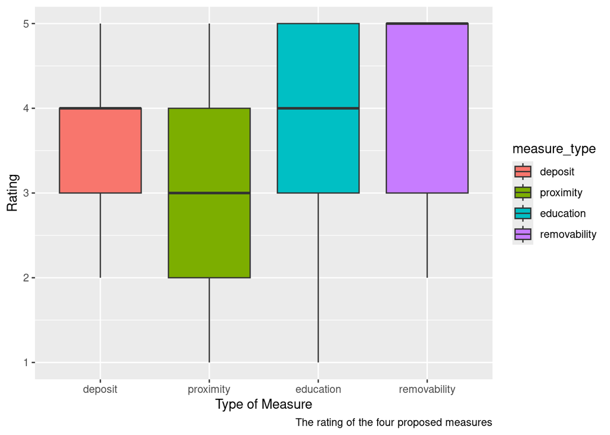

```r
tidydata |>
  ggplot(mapping = aes(x = measure_type,
                     y = measure_rating,
                     fill = measure_type)) +
  geom_boxplot(outlier.shape = NA) +
  scale_x_discrete(labels = c("deposit", "proximity", "education", "removability")) +
  scale_fill_discrete(labels = c("deposit", "proximity", "education", "removability"))+
  labs(
    x = "Type of Measure",
    y = "Rating",
    caption = "The rating of the four proposed measures")
```

### Correlation current walking distance to proximity measure rating

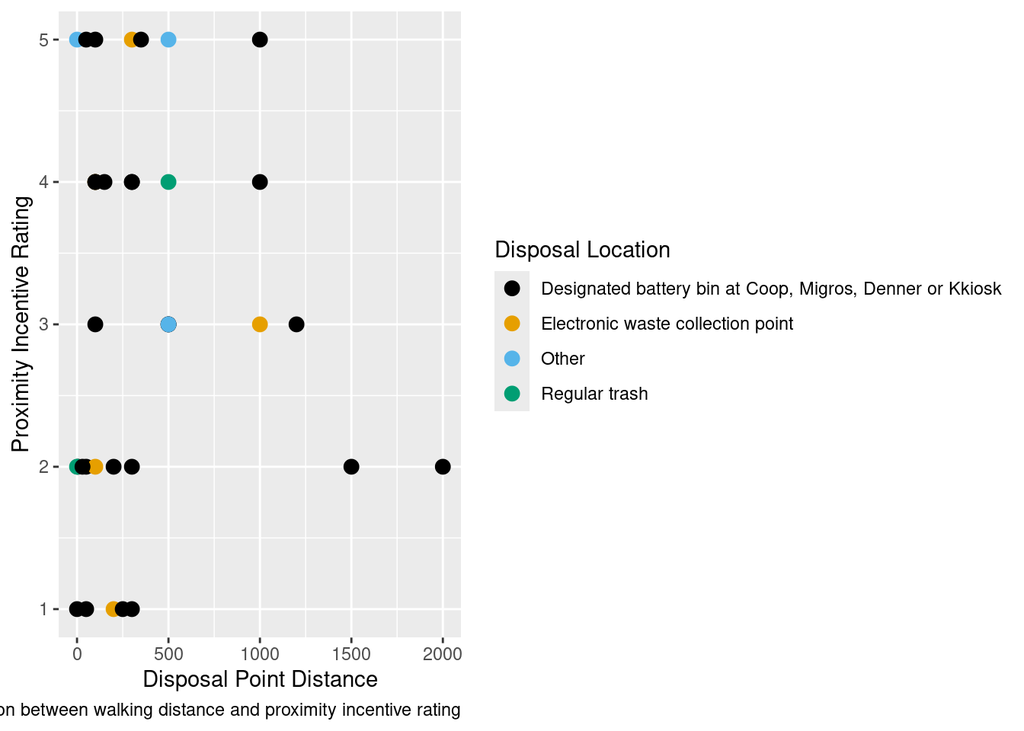

```r
tidydata_wide |>
  ggplot(aes(x = disposal_distance, y = distance_incentive_rating, color = disposal_location)) +
  geom_point(alpha = 1, size = 3) +
  scale_color_colorblind() +
  labs(
    x = "Disposal Point Distance",
    y = "Proximity Incentive Rating",
    color = "Disposal Location",
    caption = "Correlation between walking distance and proximity incentive rating"
  )
```

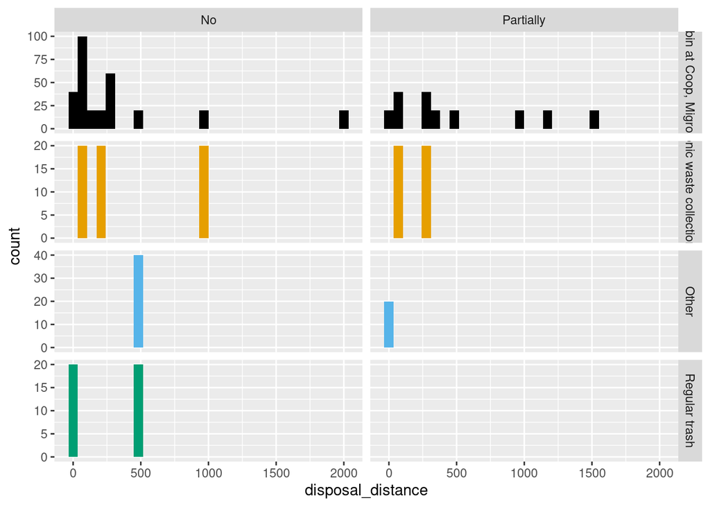

```r
tidydata |>
  ggplot(mapping = aes(x = disposal_distance, fill = disposal_location)) +
  geom_histogram() +
  facet_grid(disposal_location ~ battery_fires_knowledge, scales = "free_y") +
  scale_fill_colorblind() +
  theme(legend.position = "none")
```

## References

Batrec. (n.d.). INOBAT system. In *Batrec Industrie AG*.

Characteristics of effective battery recycling slogans: A Swiss field study. (2009). *Resources, Conservation and Recycling*, *53*(4), 218–230. https://doi.org/10.1016/j.resconrec.2008.12.003

Justifications and self-organization as determinants of recycling behavior: The case of used batteries. (2006). *Resources, Conservation and Recycling*, *47*(2), 133–159. https://doi.org/10.1016/j.resconrec.2005.10.006

Recycling of spent lithium-ion batteries as a sustainable solution to obtain raw materials for different applications. (2023). *Journal of Energy Chemistry*, *79*, 118–134. https://doi.org/10.1016/j.jechem.2022.08.005